# Poisson Claim Frequency: Fisher Information, Likelihood Ratio Tests, and Confidence Intervals

ED Distributions in Insurance

octobre 08, 2026

# Aim

We model individual claim counts as

$$Y_i \sim \operatorname{Poisson}(d_i\lambda),$$

where:

- $Y_i$ is the number of claims for policy $i$;
- $d_i$ is the policy exposure;
- $\lambda$ is the annual claim frequency.

For the grouped data below, the maximum likelihood estimator is

$$\widehat{\lambda}
=
\frac{\sum_i Y_i}{\sum_i d_i}.$$

This document illustrates:

1. the log-likelihood and its quadratic approximation;
2. observed Fisher information;
3. likelihood-ratio and Wald tests;
4. confidence intervals obtained by inverting tests;
5. the effect of more exposure on inference.

# Data

```r
claims <- c(0, 1, 2, 3, 4)

policy_counts <- c(
  12962,
  1369,
  157,
  14,
  3
)

exposures <- c(
  10545.94,
  1187.13,
  134.66,
  11.08,
  2.52
)

claim_data <- data.frame(
  claims = claims,
  policy_counts = policy_counts,
  exposures = exposures
)

knitr::kable(
  claim_data,
  col.names = c("Number of claims", "Number of policies", "Total exposure")
)
```

| Number of claims | Number of policies | Total exposure |
| --- | --- | --- |
| 0 | 12962 | 10545.94 |
| 1 | 1369 | 1187.13 |
| 2 | 157 | 134.66 |
| 3 | 14 | 11.08 |
| 4 | 3 | 2.52 |

```r
total_claims <- sum(claims * policy_counts)
total_exposure <- sum(exposures)

lambda_hat <- total_claims / total_exposure

cat("Total claims:", total_claims, "\n")
```

```
## Total claims: 1737
```

```r
cat("Total exposure:", round(total_exposure, 2), "policy-years\n")
```

```
## Total exposure: 11881.33 policy-years
```

```r
cat("MLE of lambda:", round(lambda_hat, 5), "\n")
```

```
## MLE of lambda: 0.1462
```

# Poisson log-likelihood

For grouped data, all policies in a row are represented by their average exposure:

$$d_j = \frac{D_j}{n_j},$$

where $D_j$ is total exposure and $n_j$ is the number of policies in group $j$.

The log-likelihood, including constants, is:

$$\ell(\lambda)
=
\sum_j \left[
-\lambda D_j
+
n_j y_j\log(\lambda)
+
n_j y_j\log(d_j)
-
n_j\log(y_j!)
\right].$$

```r
loglik <- function(lambda, exposures, claims, policy_counts) {
  if (any(lambda <= 0)) {
    return(-Inf)
  }

  average_exposure <- exposures / policy_counts

  sum(
    -lambda * exposures +
      policy_counts * claims * log(lambda) +
      policy_counts * claims * log(average_exposure) -
      policy_counts * lfactorial(claims)
  )
}

loglik_hat <- loglik(
  lambda = lambda_hat,
  exposures = exposures,
  claims = claims,
  policy_counts = policy_counts
)

loglik_hat
```

```
## [1] -5475.615
```

# Fisher information and quadratic likelihood approximation

For this Poisson model,

$$\ell'(\lambda)
=
-\sum_i d_i+\frac{\sum_i Y_i}{\lambda},$$

and

$$\ell''(\lambda)
=
-\frac{\sum_i Y_i}{\lambda^2}.$$

At the MLE, since $\sum_iY_i=\widehat{\lambda}\sum_i d_i$,

$$-\ell''(\widehat{\lambda})
=
\frac{\sum_i d_i}{\widehat{\lambda}}.$$

This is the **observed Fisher information**. The expected Fisher information is

$$\mathcal I(\lambda)
=
\frac{\sum_i d_i}{\lambda}.$$

At the MLE, the observed and expected information coincide.

```r
observed_information <- total_exposure / lambda_hat
expected_information_at_hat <- total_exposure / lambda_hat

var_lambda_hat <- 1 / observed_information
se_lambda_hat <- sqrt(var_lambda_hat)

cat("Observed Fisher information:", round(observed_information, 2), "\n")
```

```
## Observed Fisher information: 81270.01
```

```r
cat("Estimated variance of lambda_hat:", signif(var_lambda_hat, 5), "\n")
```

```
## Estimated variance of lambda_hat: 1.2305e-05
```

```r
cat("Estimated standard error of lambda_hat:", round(se_lambda_hat, 5), "\n")
```

```
## Estimated standard error of lambda_hat: 0.00351
```

The usual large-sample approximation is

$$\widehat{\lambda}
\overset{a}{\sim}
\mathcal N\left(
\lambda,
\frac{\lambda}{\sum_i d_i}
\right).$$

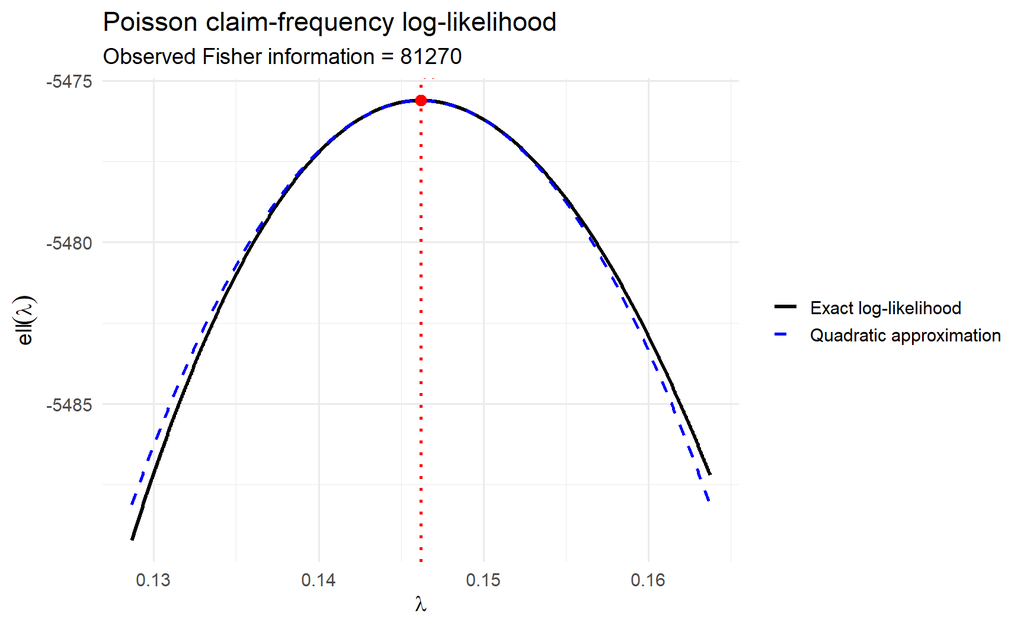

```r
lambdas <- seq(
  from = max(0.001, lambda_hat - 5 * se_lambda_hat),
  to = lambda_hat + 5 * se_lambda_hat,
  length.out = 1000
)

curve_approx <- function(lambda) {
  loglik_hat -
    0.5 * observed_information * (lambda - lambda_hat)^2
}

plot_data <- data.frame(
  lambda = lambdas,
  loglik = sapply(
    lambdas,
    loglik,
    exposures = exposures,
    claims = claims,
    policy_counts = policy_counts
  ),
  quadratic_approximation = curve_approx(lambdas)
)

ggplot(plot_data, aes(x = lambda)) +
  geom_line(
    aes(y = loglik, colour = "Exact log-likelihood"),
    linewidth = 1.1
  ) +
  geom_line(
    aes(y = quadratic_approximation, colour = "Quadratic approximation"),
    linewidth = 1,
    linetype = "dashed"
  ) +
  geom_vline(
    xintercept = lambda_hat,
    colour = "red",
    linetype = "dotted",
    linewidth = 1
  ) +
  geom_point(
    data = data.frame(lambda = lambda_hat, loglik = loglik_hat),
    aes(x = lambda, y = loglik),
    inherit.aes = FALSE,
    colour = "red",
    size = 3
  ) +
  annotate(
    "text",
    x = lambda_hat,
    y = loglik_hat,
    label = expression(hat(lambda)),
    colour = "red",
    hjust = -0.2,
    vjust = -0.8,
    parse = TRUE,
    size = 5
  ) +
  scale_colour_manual(
    values = c(
      "Exact log-likelihood" = "black",
      "Quadratic approximation" = "blue"
    )
  ) +
  labs(
    title = "Poisson claim-frequency log-likelihood",
    subtitle = paste(
      "Observed Fisher information =",
      round(observed_information, 1)
    ),
    x = expression(lambda),
    y = expression(ell(lambda)),
    colour = NULL
  ) +
  theme_minimal(base_size = 14)
```

# Likelihood-ratio test

Suppose that we want to test

$$H_0:\lambda=\lambda_0
\qquad\text{against}\qquad
H_a:\lambda\neq\lambda_0.$$

The likelihood-ratio statistic is

$$-2\log\Lambda
=
2\left[
\ell(\widehat{\lambda})-\ell(\lambda_0)
\right].$$

Under $H_0$, for a sufficiently large sample,

$$-2\log\Lambda
\overset{a}{\sim}
\chi^2_1.$$

We reject $H_0$ at level $\alpha$ when

$$-2\log\Lambda > \chi^2_{1,1-\alpha}.$$

## Example: test a tariff frequency assumption

Here, test whether the annual claim frequency equals $0.15$:

$$H_0:\lambda=0.15.$$

```r
lambda_0 <- 0.15
alpha <- 0.05

loglik_null <- loglik(
  lambda = lambda_0,
  exposures = exposures,
  claims = claims,
  policy_counts = policy_counts
)

lr_statistic <- 2 * (loglik_hat - loglik_null)
lr_critical_value <- qchisq(1 - alpha, df = 1)
lr_p_value <- pchisq(lr_statistic, df = 1, lower.tail = FALSE)

lr_results <- data.frame(
  quantity = c(
    "Null value lambda_0",
    "MLE lambda_hat",
    "LR statistic",
    "5% critical value",
    "p-value"
  ),
  value = c(
    lambda_0,
    lambda_hat,
    lr_statistic,
    lr_critical_value,
    lr_p_value
  )
)

knitr::kable(lr_results, digits = 5)
```

| quantity | value |
| --- | --- |
| Null value lambda_0 | 0.15000 |
| MLE lambda_hat | 0.14620 |
| LR statistic | 1.15615 |
| 5% critical value | 3.84146 |
| p-value | 0.28227 |

```r
if (lr_p_value < alpha) {
  cat(
    "Decision: reject H0 at the", alpha * 100,
    "% significance level.\n"
  )
} else {
  cat(
    "Decision: do not reject H0 at the", alpha * 100,
    "% significance level.\n"
  )
}
```

```
## Decision: do not reject H0 at the 5 % significance level.
```

## Visualising the LR test

The horizontal line represents the log-likelihood cutoff corresponding to the 5% LR test:

$$\ell(\lambda)
=
\ell(\widehat{\lambda})
-
\frac{1}{2}\chi^2_{1,0.95}.$$

Values of $\lambda$ below this line are rejected by the LR test.

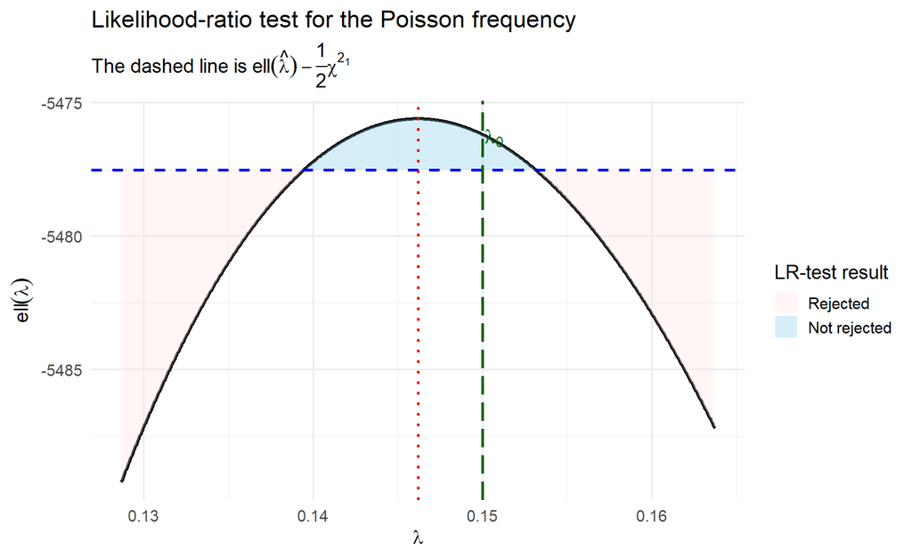

```r
lr_cutoff_loglik <- loglik_hat - 0.5 * lr_critical_value

plot_data$accepted_by_lr <- plot_data$loglik >= lr_cutoff_loglik

ggplot(plot_data, aes(x = lambda, y = loglik)) +
  geom_line(linewidth = 1.1, colour = "black") +
  geom_ribbon(
    aes(
      ymin = lr_cutoff_loglik,
      ymax = loglik,
      fill = accepted_by_lr
    ),
    alpha = 0.35
  ) +
  geom_hline(
    yintercept = lr_cutoff_loglik,
    linetype = "dashed",
    colour = "blue",
    linewidth = 1
  ) +
  geom_vline(
    xintercept = c(lambda_hat, lambda_0),
    linetype = c("dotted", "longdash"),
    colour = c("red", "darkgreen"),
    linewidth = 1
  ) +
  annotate(
    "text",
    x = lambda_hat,
    y = max(plot_data$loglik),
    label = expression(hat(lambda)),
    colour = "red",
    hjust = -0.1,
    vjust = -0.8,
    parse = TRUE,
    size = 5
  ) +
  annotate(
    "text",
    x = lambda_0,
    y = max(plot_data$loglik),
    label = expression(lambda[0]),
    colour = "darkgreen",
    hjust = -0.1,
    vjust = 1.5,
    parse = TRUE,
    size = 5
  ) +
  scale_fill_manual(
    values = c(
      "TRUE" = "skyblue",
      "FALSE" = "mistyrose"
    ),
    labels = c(
      "TRUE" = "Not rejected",
      "FALSE" = "Rejected"
    )
  ) +
  labs(
    title = "Likelihood-ratio test for the Poisson frequency",
    subtitle = expression(
      paste(
        "The dashed line is ",
        ell(hat(lambda)) - frac(1, 2) * chi^2[1, 0.95]
      )
    ),
    x = expression(lambda),
    y = expression(ell(lambda)),
    fill = "LR-test result"
  ) +
  theme_minimal(base_size = 14)
```

# Wald test

The Wald statistic for testing $H_0:\lambda=\lambda_0$ is

$$Z
=
\frac{\widehat{\lambda}-\lambda_0}
{\widehat{\operatorname{se}}(\widehat{\lambda})}.$$

Under $H_0$,

$$Z\overset{a}{\sim}\mathcal N(0,1),
\qquad
Z^2\overset{a}{\sim}\chi^2_1.$$

```r
wald_z <- (lambda_hat - lambda_0) / se_lambda_hat
wald_chisq <- wald_z^2
wald_p_value <- 2 * pnorm(abs(wald_z), lower.tail = FALSE)

wald_results <- data.frame(
  quantity = c(
    "Wald Z statistic",
    "Wald chi-square statistic",
    "Two-sided p-value"
  ),
  value = c(
    wald_z,
    wald_chisq,
    wald_p_value
  )
)

knitr::kable(wald_results, digits = 5)
```

| quantity | value |
| --- | --- |
| Wald Z statistic | -1.08451 |
| Wald chi-square statistic | 1.17616 |
| Two-sided p-value | 0.27814 |

The LR and Wald tests will often give similar conclusions for large samples. However, the LR test uses the shape of the likelihood directly and can behave better when the likelihood is asymmetric or when a parameter is near a boundary.

# Confidence intervals by test inversion

A $100(1-\alpha)\%$ confidence set is the set of null parameter values that are **not rejected** by a level-$\alpha$ test.

For the LR confidence interval:

$$\left\{
\lambda:
2\left[
\ell(\widehat{\lambda})-\ell(\lambda)
\right]
\leq
\chi^2_{1,1-\alpha}
\right\}.$$

```r
lr_difference <- function(lambda) {
  2 * (
    loglik_hat -
      loglik(
        lambda = lambda,
        exposures = exposures,
        claims = claims,
        policy_counts = policy_counts
      )
  ) - lr_critical_value
}

lr_ci_lower <- uniroot(
  lr_difference,
  interval = c(1e-10, lambda_hat)
)$root

lr_ci_upper <- uniroot(
  lr_difference,
  interval = c(lambda_hat, max(1, 5 * lambda_hat))
)$root

lr_ci <- c(lower = lr_ci_lower, upper = lr_ci_upper)
lr_ci
```

```
##     lower     upper
## 0.1394252 0.1531909
```

The Wald interval is

$$\widehat{\lambda}
\pm
z_{1-\alpha/2}
\widehat{\operatorname{se}}(\widehat{\lambda}).$$

```r
z_critical_value <- qnorm(1 - alpha / 2)

wald_ci <- lambda_hat +
  c(-1, 1) * z_critical_value * se_lambda_hat

ci_results <- data.frame(
  method = c("Likelihood-ratio interval", "Wald interval"),
  lower = c(lr_ci[1], wald_ci[1]),
  upper = c(lr_ci[2], wald_ci[2])
)

knitr::kable(ci_results, digits = 5)
```

|  | method | lower | upper |
| --- | --- | --- | --- |
| lower | Likelihood-ratio interval | 0.13943 | 0.15319 |
|  | Wald interval | 0.13932 | 0.15307 |

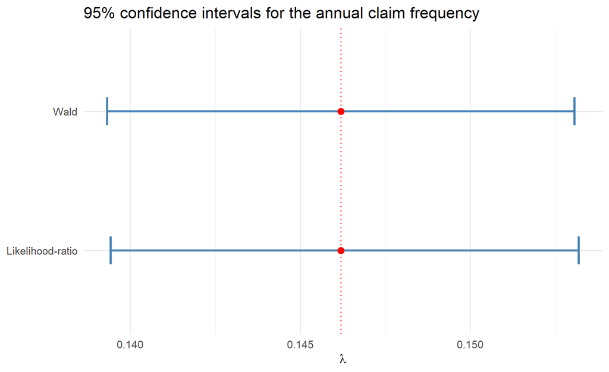

```r
ci_plot_data <- data.frame(
  method = c("Likelihood-ratio", "Wald"),
  lower = c(lr_ci[1], wald_ci[1]),
  upper = c(lr_ci[2], wald_ci[2]),
  estimate = lambda_hat
)

ggplot(ci_plot_data, aes(y = method)) +
  geom_errorbarh(
    aes(xmin = lower, xmax = upper),
    height = 0.2,
    linewidth = 1.1,
    colour = "steelblue"
  ) +
  geom_point(
    aes(x = estimate),
    size = 3,
    colour = "red"
  ) +
  geom_vline(
    xintercept = lambda_hat,
    linetype = "dotted",
    colour = "red"
  ) +
  labs(
    title = "95% confidence intervals for the annual claim frequency",
    x = expression(lambda),
    y = NULL
  ) +
  theme_minimal(base_size = 14)
```

# Effect of exposure on Fisher information and LR tests

To illustrate the effect of more data, we multiply both:

- all policy counts; and
- all exposures

by the same factor.

This keeps the empirical claim frequency $\widehat{\lambda}$ fixed while changing the amount of information. In a real portfolio, this corresponds approximately to observing a larger portfolio with the same claim-frequency experience.

Because

$$\mathcal I(\widehat{\lambda})
=
\frac{\sum_i d_i}{\widehat{\lambda}},$$

Fisher information increases linearly with exposure, while the standard error decreases at rate

$$\widehat{\operatorname{se}}(\widehat{\lambda})
\propto
\frac{1}{\sqrt{\sum_i d_i}}.$$

```r
scenarios <- data.frame(
  scenario = c("One quarter of portfolio", "Observed portfolio", "Ten times portfolio"),
  multiplier = c(0.25, 1, 10)
)

scenario_results <- do.call(
  rbind,
  lapply(seq_len(nrow(scenarios)), function(i) {
    multiplier <- scenarios$multiplier[i]

    exposures_scaled <- exposures * multiplier
    policy_counts_scaled <- policy_counts * multiplier

    total_exposure_scaled <- sum(exposures_scaled)
    total_claims_scaled <- sum(claims * policy_counts_scaled)
    lambda_hat_scaled <- total_claims_scaled / total_exposure_scaled

    information_scaled <- total_exposure_scaled / lambda_hat_scaled
    se_scaled <- sqrt(1 / information_scaled)

    data.frame(
      scenario = scenarios$scenario[i],
      multiplier = multiplier,
      total_exposure = total_exposure_scaled,
      lambda_hat = lambda_hat_scaled,
      fisher_information = information_scaled,
      standard_error = se_scaled,
      ci_lower = lambda_hat_scaled - z_critical_value * se_scaled,
      ci_upper = lambda_hat_scaled + z_critical_value * se_scaled
    )
  })
)

knitr::kable(scenario_results, digits = 5)
```

| scenario | multiplier | total_exposure | lambda_hat | fisher_information | standard_error | ci_lower | ci_upper |
| --- | --- | --- | --- | --- | --- | --- | --- |
| One quarter of portfolio | 0.25 | 2970.332 | 0.1462 | 20317.50 | 0.00702 | 0.13245 | 0.15995 |
| Observed portfolio | 1.00 | 11881.330 | 0.1462 | 81270.01 | 0.00351 | 0.13932 | 0.15307 |
| Ten times portfolio | 10.00 | 118813.300 | 0.1462 | 812700.07 | 0.00111 | 0.14402 | 0.14837 |

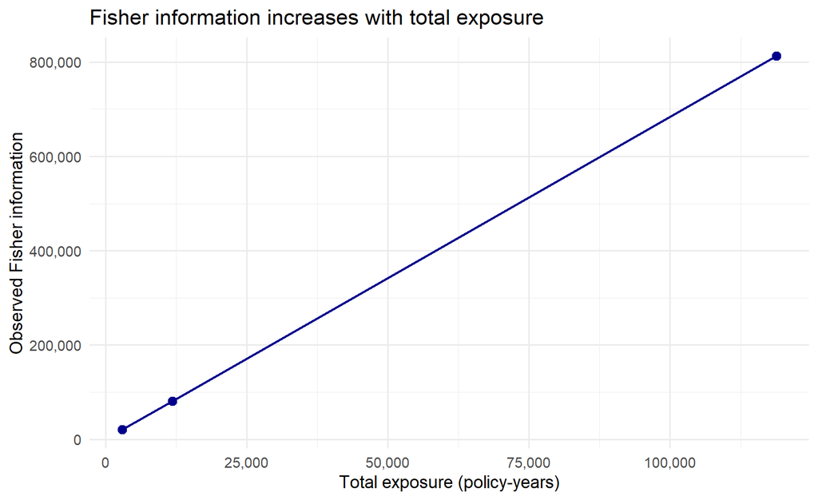

```r
ggplot(
  scenario_results,
  aes(x = total_exposure, y = fisher_information)
) +
  geom_point(size = 3, colour = "darkblue") +
  geom_line(linewidth = 1, colour = "darkblue") +
  scale_x_continuous(labels = scales::comma) +
  scale_y_continuous(labels = scales::comma) +
  labs(
    title = "Fisher information increases with total exposure",
    x = "Total exposure (policy-years)",
    y = "Observed Fisher information"
  ) +
  theme_minimal(base_size = 14)
```

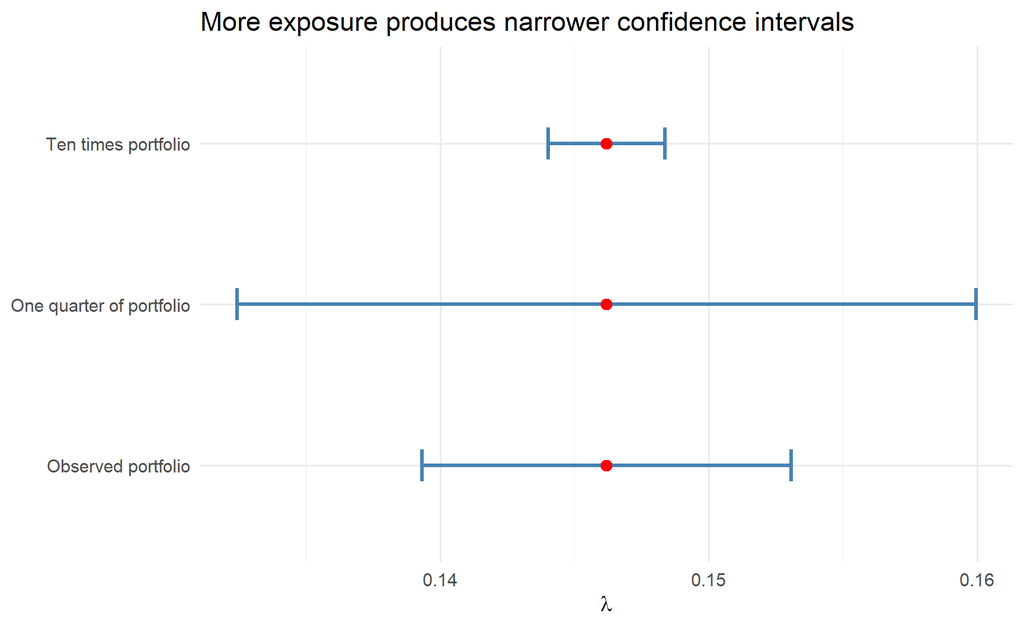

```r
ggplot(scenario_results, aes(y = scenario)) +
  geom_errorbarh(
    aes(xmin = ci_lower, xmax = ci_upper),
    height = 0.2,
    linewidth = 1.1,
    colour = "steelblue"
  ) +
  geom_point(
    aes(x = lambda_hat),
    size = 3,
    colour = "red"
  ) +
  labs(
    title = "More exposure produces narrower confidence intervals",
    x = expression(lambda),
    y = NULL
  ) +
  theme_minimal(base_size = 14)
```

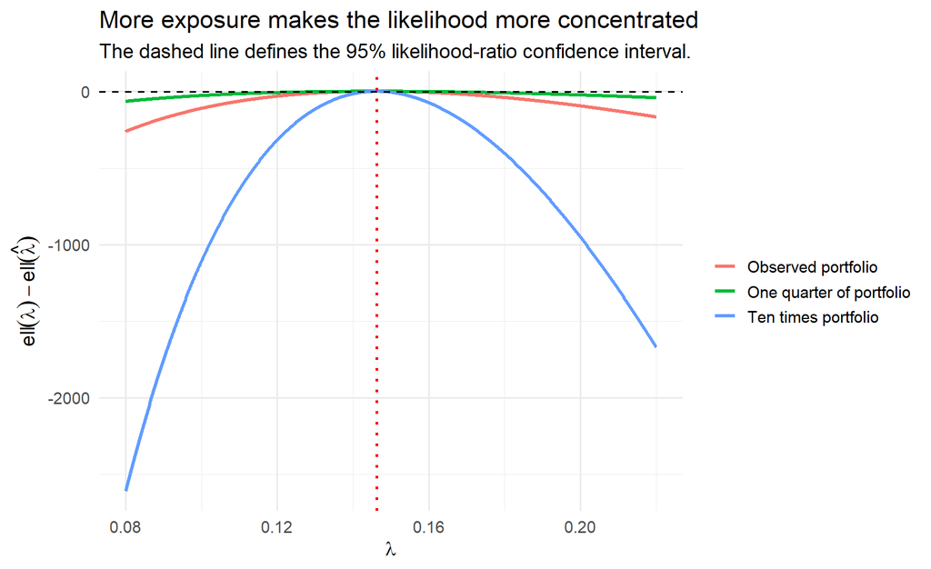

```r
lambdas <- seq(0.08, 0.22, length.out = 1000)

likelihood_scenarios <- do.call(
  rbind,
  lapply(seq_len(nrow(scenarios)), function(i) {
    multiplier <- scenarios$multiplier[i]

    exposures_scaled <- exposures * multiplier
    policy_counts_scaled <- policy_counts * multiplier

    lambda_hat_scaled <-
      sum(claims * policy_counts_scaled) / sum(exposures_scaled)

    ll_values <- sapply(
      lambdas,
      loglik,
      exposures = exposures_scaled,
      claims = claims,
      policy_counts = policy_counts_scaled
    )

    ll_at_mle <- loglik(
      lambda = lambda_hat_scaled,
      exposures = exposures_scaled,
      claims = claims,
      policy_counts = policy_counts_scaled
    )

    data.frame(
      lambda = lambdas,
      relative_loglikelihood = ll_values - ll_at_mle,
      scenario = scenarios$scenario[i]
    )
  })
)

ggplot(
  likelihood_scenarios,
  aes(
    x = lambda,
    y = relative_loglikelihood,
    colour = scenario
  )
) +
  geom_line(linewidth = 1.1) +
  geom_hline(yintercept = -0.5 * lr_critical_value, linetype = "dashed") +
  geom_vline(
    xintercept = lambda_hat,
    colour = "red",
    linetype = "dotted",
    linewidth = 1
  ) +
  labs(
    title = "More exposure makes the likelihood more concentrated",
    subtitle = "The dashed line defines the 95% likelihood-ratio confidence interval.",
    x = expression(lambda),
    y = expression(
      ell(lambda) - ell(hat(lambda))
    ),
    colour = NULL
  ) +
  theme_minimal(base_size = 14)
```

# Key messages

1. The curvature of the log-likelihood at the MLE is the observed Fisher information:

   $$\mathcal J(\widehat{\lambda})
   =
   -\ell''(\widehat{\lambda}).$$
2. More policy exposure increases Fisher information and reduces the standard error of $\widehat{\lambda}$.
3. The likelihood-ratio statistic compares the unconstrained MLE with a parameter value imposed by the null hypothesis:

   $$-2\log\Lambda
   =
   2\left[
   \ell(\widehat{\lambda})-\ell(\lambda_0)
   \right].$$
4. A confidence interval can be obtained by retaining all null values not rejected by a hypothesis test.
5. For this one-parameter Poisson model and a large portfolio, the LR and Wald intervals are close. In more complicated models, profile likelihood intervals can be preferable because they use the shape of the likelihood directly.